# Red Wine Quality Exploration

# Multivariate Plots Section

In this section, we will use 3 variables simultaneously to conduct some further investigations. Namely, we want to see whether the strong correlations we found in our bivariate analysis hold true for all the different quality levels of the red wine.

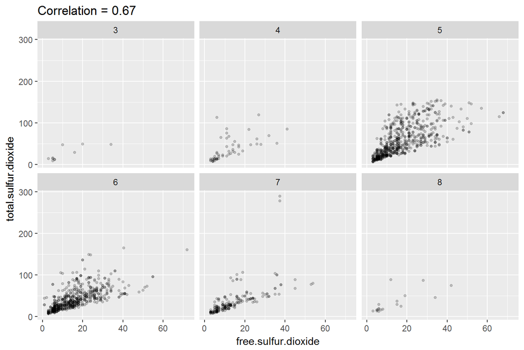

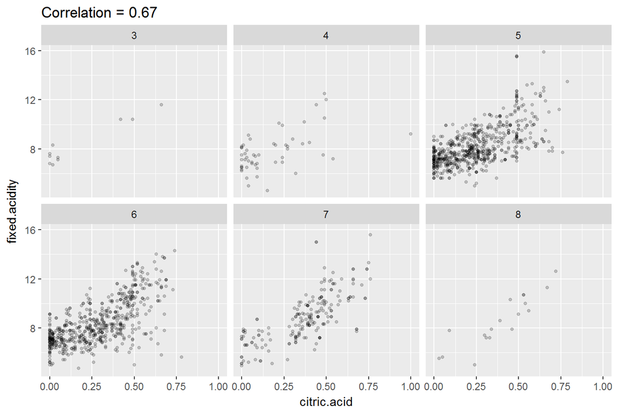

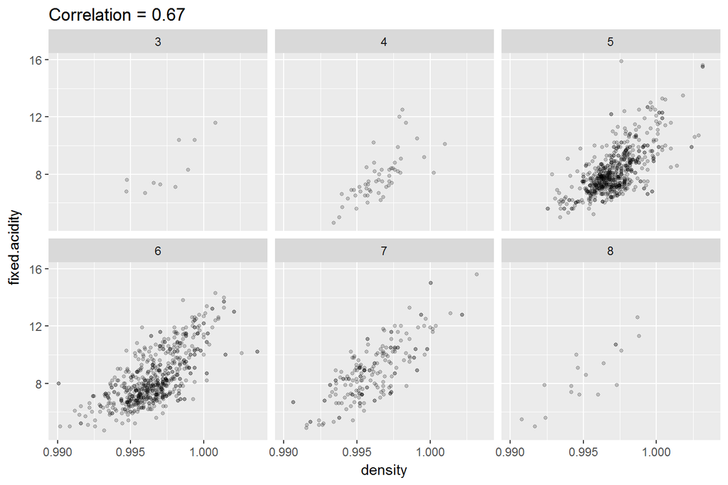

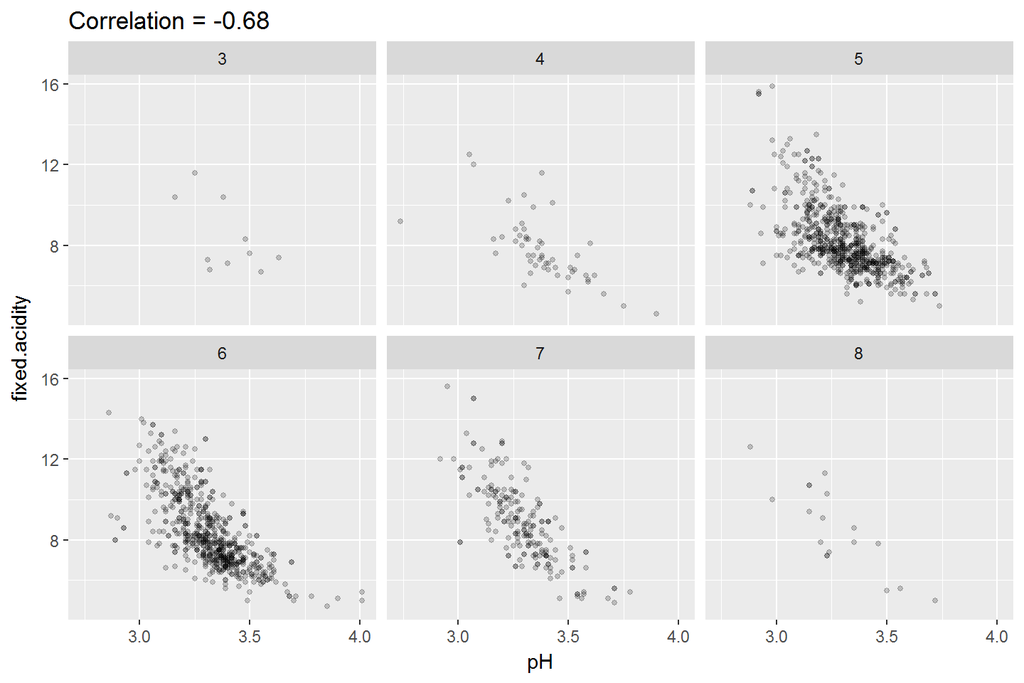

We can notice that the correlations hold for every quality level. However, there are much less observations for the quality levels of 3 and 8. That’s because there are less red wines with those quality levels in our dataset. The most dense scatterplots are for the quality levels of 5 and 6, which is in line with our data. The most frequent quality of red wines in our data set is 5 and 6.

Now we will analyze two pairs of variables that are rather negatively correlated (citric acid and volatile acidity, citric acid and pH). We would like to see whether there is variation in the correlation between these variables for different quality levels of red wine.

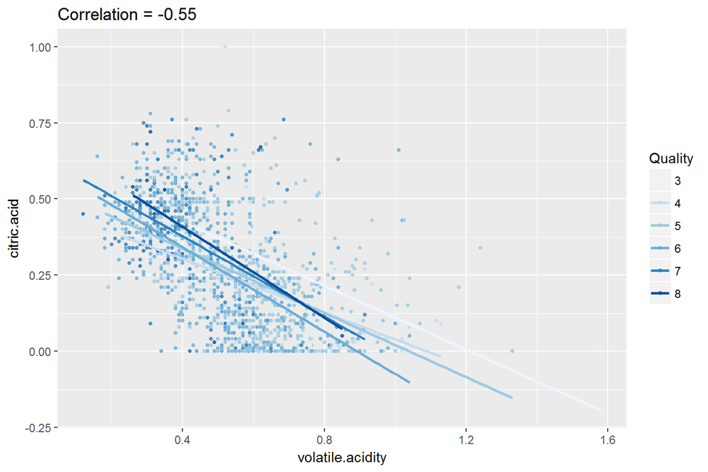

The negative correlation of -0.55 between volatile acidity and citric acid is shown in this graph. The slopes of the lines fitted through the points are relatively flat. This makes sense because these slopes resemble the correlation coefficient between the variables. Notice that for every quality level, there is a slight difference between the slopes of the lines. I.e. the correlation between citric acid and volatile acidity slightly differs among the different quality levels.

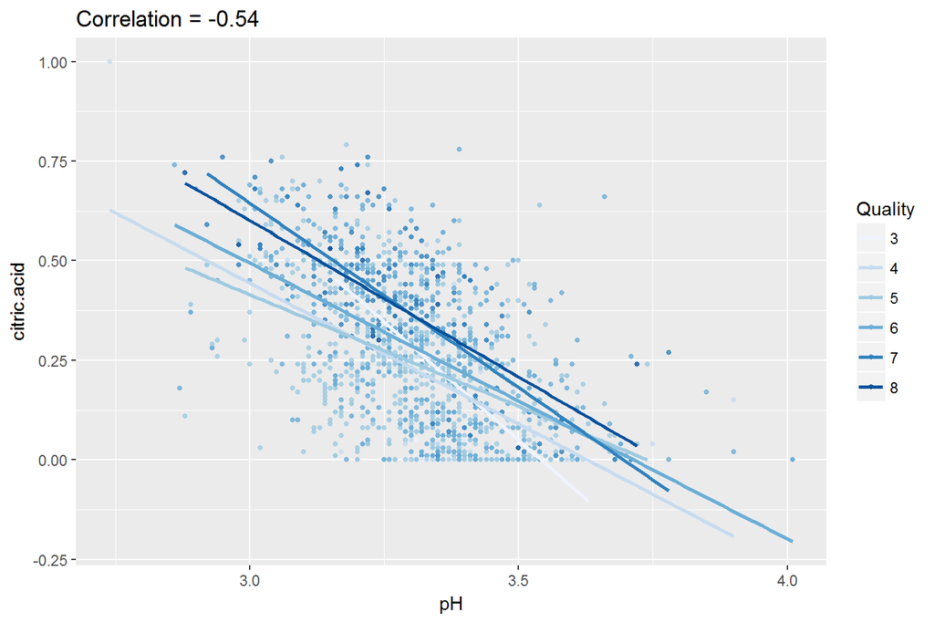

The same logic goes for the negative correlation of -0.54 between pH and citric acid. The variation in the slopes of the lines shows that the correlation between these variables slightly differs by quality level. We can notice that the steepest lines is for the quality level of 3. I.e. the most negative correlation between pH and citric acid occurs for the red wines with the quality level of 3.

We will now model the relationships between the chemical properties and the quality of red wine. We will use different variables in our models to see which one is better. We will start with the variables that are most correlated with the quality of red wine. And we will apply the log10 transformations if necessary, to use normally distributed independent variables.

```
##
## Calls:
## model1: lm(formula = I(quality) ~ I(log10(alcohol)), data = redwine)
## model2: lm(formula = I(quality) ~ I(log10(alcohol)) + log10(volatile.acidity),
##     data = redwine)
## model3: lm(formula = I(quality) ~ I(log10(alcohol)) + log10(volatile.acidity) +
##     log10(sulphates), data = redwine)
## model4: lm(formula = I(quality) ~ I(log10(alcohol)) + log10(volatile.acidity) +
##     log10(sulphates) + log10(citric.acid + 1), data = redwine)
##
## =======================================================================
##                             model1     model2     model3     model4
## -----------------------------------------------------------------------
##   (Intercept)             -5.474***  -4.648***  -4.023***  -3.983***
##                           (0.420)    (0.401)    (0.399)    (0.401)
##   I(log10(alcohol))        8.968***   7.687***   7.440***   7.417***
##                           (0.414)    (0.401)    (0.394)    (0.394)
##   log10(volatile.acidity)            -1.565***  -1.299***  -1.371***
##                                      (0.112)    (0.114)    (0.134)
##   log10(sulphates)                               1.514***   1.552***
##                                                 (0.177)    (0.181)
##   log10(citric.acid + 1)                                   -0.314
##                                                            (0.310)
## -----------------------------------------------------------------------
##   R-squared                    0.2        0.3        0.3        0.3
##   adj. R-squared               0.2        0.3        0.3        0.3
##   sigma                        0.7        0.7        0.7        0.7
##   F                          470.3      361.0      275.8      207.1
##   p                            0.0        0.0        0.0        0.0
##   Log-likelihood           -1720.3    -1628.3    -1592.5    -1592.0
##   Deviance                   805.1      717.6      686.2      685.8
##   AIC                       3446.5     3264.5     3195.1     3196.0
##   BIC                       3462.6     3286.0     3222.0     3228.3
##   N                         1599       1599       1599       1599
## =======================================================================
```